# SIG17 CRISPR screen — Gata3 analysis (MAGeCK test)

EYW

2026-08-12

```r
library(tidyverse)
library(patchwork)
library(ggrepel)
library(RColorBrewer)
library(scales)
knitr::opts_chunk$set(echo = TRUE, message = FALSE, warning = FALSE)
```

```r
source("../../functions/r_custom/plotting_fxns.R")
theme_set(theme_Publication())
```

# Goal

Focus on the **Gata3** arm of the SIG17 CRISPR screen (TGFb + TNF condition). Naive CD4 T cells were perturbed, then sorted into 4 bins by GATA3-reporter expression (bin 1 = lowest, bin 4 = highest). Each higher bin is compared to bin 1 with `mageck test`, so a positive gene-level LFC means a gene’s sgRNAs are **enriched** in cells with higher GATA3 (knockout pushes cells toward high GATA3), and a negative LFC means **depleted** (knockout pushes toward low GATA3).

# Import

```r
pipe_dir <- "/data1/rudenska/EYW/SIG17_redo/dedup_pipeline/output"
test_dir <- file.path(pipe_dir, "05_mageck_test_dedup")

# MAGeCK test gene-level summaries: bins 2/3/4 vs bin 1
test_files <- c(`2` = "TGFb_TNF_gata3_2_v_1.gene_summary.txt",
                 `3` = "TGFb_TNF_gata3_3_v_1.gene_summary.txt",
                 `4` = "TGFb_TNF_gata3_4_v_1.gene_summary.txt")

gata3_test <- imap_dfr(test_files, function(f, bin) {
  read_delim(file.path(test_dir, f), show_col_types = FALSE) %>%
    transmute(
      gene = id,
      bin  = as.integer(bin),
      lfc  = `neg|lfc`,
      # neg|lfc and pos|lfc are identical; take the fdr from whichever test
      # direction matches the sign of the lfc.
      fdr  = if_else(`neg|lfc` > 0, `pos|fdr`, `neg|fdr`)
    )
})

# MAGeCK test sgRNA-level LFC for the highest bin (bin 4 vs bin 1).
# Only the `test` output carries a per-sgRNA LFC, which the density/tick plot needs.
sgHi <- read_delim(file.path(test_dir, "TGFb_TNF_gata3_4_v_1.sgrna_summary.txt"),
                   show_col_types = FALSE)
```

```r
# add the baseline bin (bin 1): lfc = 0 by construction, no test so fdr = NA
gata3_test <- gata3_test %>%
  bind_rows(
    distinct(gata3_test, gene) %>% mutate(bin = 1L, lfc = 0, fdr = NA_real_)
  ) %>%
  arrange(gene, bin)

# direction / significance call used throughout
sig_thresh <- 0.1
gata3_test <- gata3_test %>%
  mutate(
    significant = !is.na(fdr) & fdr < sig_thresh,
    direction = case_when(
      significant & lfc > 0 ~ "enriched (high GATA3)",
      significant & lfc < 0 ~ "depleted (low GATA3)",
      TRUE ~ "n.s."
    )
  )

dir_pal <- c("enriched (high GATA3)" = "#3B6FB6",
             "depleted (low GATA3)"  = "#C0392B",
             "n.s."                  = "grey75")
```

# Volcano plot (bin 4 vs bin 1)

Gene-level LFC vs -log10(FDR) from the `mageck test` gene summary for the TGFb + TNF GATA3 bin 4 vs bin 1 comparison.

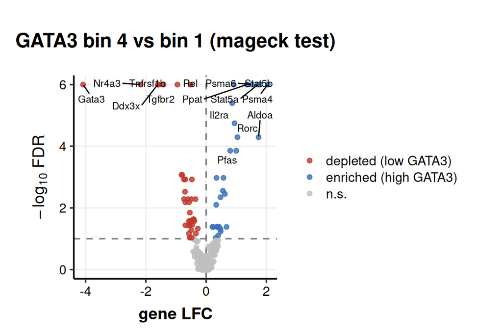

```r
ggplot(gata3_test %>% filter(bin == 4), aes(lfc, -log10(fdr), color = direction)) +
  geom_hline(yintercept = -log10(sig_thresh), linetype = "dashed", color = "grey50") +
  geom_vline(xintercept = 0, linetype = "dashed", color = "grey50") +
  geom_point(size = 1.5, alpha = 0.8) +
  geom_text_repel(
    data = . %>% filter(significant) %>% slice_max(abs(lfc), n = 15),
    aes(label = gene), color = "black", size = 3, max.overlaps = 20
  ) +
  scale_color_manual(values = dir_pal, name = NULL) +
  labs(title = "GATA3 bin 4 vs bin 1 (mageck test)",
       x = "gene LFC", y = expression(-log[10]~FDR)) +
  theme(aspect.ratio = 1)
```

```r
ggsave("../../analysis_outs/SIG17_tgfb_tnf/gata3_4_vs_1_sgRNA_volcano.pdf")
```

## CRISPR LFC vs SIG18 TGFb+TNF interaction coefficient

Same x axis as the volcano (gene-level LFC, bin 4 vs bin 1), but the y axis is the **GLM interaction coefficient** for the matching TGFb + TNF condition in the SIG18 bulk ligand-combination experiment.

```r
sig18_inter <- read_csv(
  "/data1/rudenska/EYW/git_projects/SIG18/analysis_outs/deg_updated/res_interaction_scored_SIG18.csv",
  show_col_types = FALSE
) %>%
  filter(condition == "TGFb-TNF") %>%
  # one row per gene symbol (a few symbols map to >1 ensembl ID)
  group_by(gene) %>%
  slice_min(padj_interaction, n = 1, with_ties = FALSE) %>%
  ungroup() %>%
  select(gene, lfc_interaction, padj_interaction, interaction_class)

# bin 4 CRISPR result joined to the SIG18 interaction term
crispr_vs_inter <- gata3_test %>%
  filter(bin == 4) %>%
  inner_join(sig18_inter, by = "gene")

interaction_palette <- c("none"             = "#808080",
                         "buffering"        = "#D95F02FF",
                         "synergy negative" = "#E7298A",
                         "synergy positive" = "#1B9E77")
```

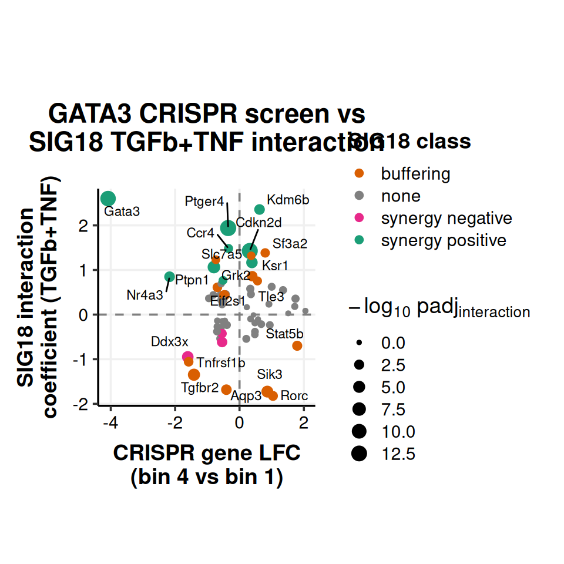

```r
inter_sig_thresh <- 0.1

crispr_vs_inter %>%
  # filter for significant CRISPR hits
  filter(fdr < 0.1) %>%
  ggplot(aes(lfc, lfc_interaction)) +
  geom_hline(yintercept = 0, linetype = "dashed", color = "grey50") +
  geom_vline(xintercept = 0, linetype = "dashed", color = "grey50") +
  geom_point(aes(color = interaction_class,
                 size = -log10(padj_interaction))) +
  geom_text_repel(
    data = . %>%
      filter(significant, padj_interaction < inter_sig_thresh) %>%
      slice_max(abs(lfc) * abs(lfc_interaction), n = 20),
    aes(label = gene), color = "black", size = 3, max.overlaps = 20
  ) +
  scale_color_manual(values = interaction_palette, name = "SIG18 class") +
  scale_size_continuous(range = c(0.8, 4),
                        name = expression(-log[10]~padj[interaction])) +
  labs(title = "GATA3 CRISPR screen vs\nSIG18 TGFb+TNF interaction",
       x = "CRISPR gene LFC\n(bin 4 vs bin 1)",
       y = "SIG18 interaction\ncoefficient (TGFb+TNF)") +
  theme(aspect.ratio = 1)
```

```r
ggsave("../../analysis_outs/SIG17_tgfb_tnf/gata3_4_vs_1_lfc_vs_SIG18_TGFb_TNF_interaction.pdf")
```

# Highest bin: sgRNA LFC density + per-gene tick plot

Two-panel stacked view for the highest bin (bin 4 vs bin 1), built from the per-sgRNA LFC values.

Top 30 genes by |LFC| in bin 4 are used for the gene set below; the same `bin4_lfc` lookup also feeds the curated final figure further down.

```r
gene_order <- gata3_test %>%
  filter(bin == 4) %>%
  slice_max(abs(lfc), n = 30) %>%
  arrange(lfc) %>%        # most depleted first -> bottom of plot after factor
  pull(gene)

# bin-4 lfc lookup, reused by the curated final figure to order genes
bin4_lfc <- gata3_test %>%
  filter(bin == 4) %>%
  select(gene, lfc4 = lfc)
```

```r
sg_top <- sgHi %>%
  filter(Gene %in% gene_order) %>%
  transmute(gene = factor(Gene, levels = gene_order),
            sgrna, LFC) %>%
  mutate(y = as.integer(gene),
         tick_dir = ifelse(LFC < 0, "depleted", "enriched"))

# shared x range across both panels
x_rng <- range(sgHi$LFC, na.rm = TRUE)
x_rng <- x_rng + c(-1, 1) * 0.05 * diff(x_rng)

# background grid: a fine strip of tiles per gene row, shaded by the overall
# sgRNA LFC density so the background is darkest where sgRNAs are most dense.
x_grid <- seq(x_rng[1], x_rng[2], length.out = 500)
lfc_dens <- density(sgHi$LFC, na.rm = TRUE,
                    from = x_rng[1], to = x_rng[2], n = 500)
grad_grid <- expand_grid(y = seq_along(gene_order), x = x_grid) %>%
  mutate(dens = approx(lfc_dens$x, lfc_dens$y, xout = x)$y)
```

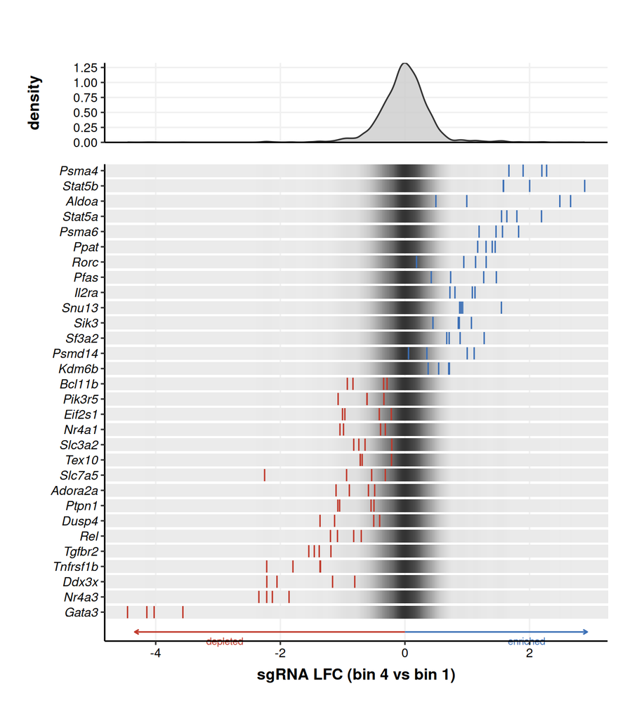

```r
# ---- top: density of sgRNA LFC ----
p_top <- ggplot(sgHi, aes(LFC)) +
  geom_density(fill = "grey80", color = "grey20", alpha = 0.8) +
  coord_cartesian(xlim = x_rng, expand = FALSE) +
  labs(y = "density") +
  theme(axis.title.x = element_blank(),
        axis.text.x = element_blank(),
        axis.ticks.x = element_blank())

# ---- bottom: per-gene gradient background + sgRNA ticks ----
p_bottom <- ggplot() +
  geom_tile(data = grad_grid, aes(x = x, y = y, fill = dens), height = 0.85) +
  scale_fill_gradient(low = "grey92", high = "grey20", guide = "none") +
  geom_segment(data = sg_top,
               aes(x = LFC, xend = LFC, y = y - 0.4, yend = y + 0.4,
                   color = tick_dir), linewidth = 0.6) +
  scale_color_manual(values = c(depleted = "#C0392B", enriched = "#3B6FB6"),
                     guide = "none") +
  scale_y_continuous(breaks = seq_along(gene_order), labels = gene_order,
                     expand = expansion(add = 0.6)) +
  coord_cartesian(xlim = x_rng, expand = FALSE, clip = "off") +
  annotate("segment", x = 0, xend = x_rng[1] * 0.9, y = -0.3, yend = -0.3,
           arrow = arrow(length = unit(0.15, "cm")), color = "#C0392B") +
  annotate("text", x = x_rng[1] * 0.6, y = -0.9, label = "depleted",
           color = "#C0392B", size = 3.2) +
  annotate("segment", x = 0, xend = x_rng[2] * 0.9, y = -0.3, yend = -0.3,
           arrow = arrow(length = unit(0.15, "cm")), color = "#3B6FB6") +
  annotate("text", x = x_rng[2] * 0.6, y = -0.9, label = "enriched",
           color = "#3B6FB6", size = 3.2) +
  labs(x = "sgRNA LFC (bin 4 vs bin 1)") +
  theme(axis.text.y = element_text(face = "italic"),
        axis.title.y = element_blank(),
        plot.margin = margin(5.5, 5.5, 22, 5.5))

p_top / p_bottom + plot_layout(heights = c(0.5, 3))
```

# Final Figure for Selected Genes

A manually curated gene set, traced across the sort gradient (bin 1 anchored at 0) and paired with the sgRNA LFC density/tick plot for bin 4 vs bin 1.

```r
# plot genes
plot_genes <- c("Gata3","Nr4a3","Tnfrsf1b","Ddx3x","Tgfbr2","Rel","Ptpn1", #  positive regulators
               "Il2ra","Ppat","Psma6","Aldoa","Stat5a","Stat5b","Psma4") # negative regulators
```

```r
# genes to show as rows
gene_order <- gata3_test %>%
  filter(bin == 4, gene %in% plot_genes) %>%
  arrange(lfc) %>%        # most depleted first -> bottom of plot after factor
  pull(gene)

# filter to genes to show
sg_top <- sgHi %>%
  filter(Gene %in% gene_order) %>%
  transmute(gene = factor(Gene, levels = gene_order),
            sgrna, LFC) %>%
  mutate(y = as.integer(gene),
         tick_dir = ifelse(LFC < 0, "depleted", "enriched"))

# shared x range across both panels
x_rng <- c(-5,4)

# background grid: a fine strip of tiles per gene row, shaded by the overall
# sgRNA LFC density so the background is darkest where sgRNAs are most dense.
x_grid <- seq(x_rng[1], x_rng[2], length.out = 500)
lfc_dens <- density(sgHi$LFC, na.rm = TRUE,
                    from = x_rng[1], to = x_rng[2], n = 500)
grad_grid <- expand_grid(y = seq_along(gene_order), x = x_grid) %>%
  mutate(dens = approx(lfc_dens$x, lfc_dens$y, xout = x)$y)

# shared x breaks so the two stacked panels line up
x_breaks <- seq(ceiling(x_rng[1] / 2) * 2, floor(x_rng[2] / 2) * 2, by = 2)

# ---- top: density of sgRNA LFC ----
p_top <- ggplot(sgHi, aes(LFC)) +
  geom_density(fill = "grey80", color = "grey20", alpha = 0.8) +
  scale_x_continuous(breaks = x_breaks) +
  scale_y_continuous(limits = c(0, 1.5)) +
  coord_cartesian(xlim = x_rng, expand = FALSE) +
  labs(y = "density") +
  theme(axis.title.x = element_blank(),
        panel.grid.major = element_blank(),
        legend.position = "right",
        legend.key.size = unit(0.4, "cm"))

# ---- bottom: per-gene gradient background + sgRNA ticks ----
p_bottom <- ggplot() +
  geom_tile(data = grad_grid, aes(x = x, y = y, fill = dens), height = 0.85) +
  scale_fill_gradient(low = "grey92", high = "grey20", guide = "none") +
  geom_segment(data = sg_top,
               aes(x = LFC, xend = LFC, y = y - 0.4, yend = y + 0.4,
                   color = tick_dir), linewidth = 1) +
  scale_color_manual(values = c(depleted = "#C0392B", enriched = "#3B6FB6"),
                     guide = "none") +
  scale_y_continuous(breaks = seq_along(gene_order), labels = gene_order,
                     expand = c(0,0)) +
  scale_x_continuous(breaks = x_breaks) +
  coord_cartesian(xlim = x_rng, expand = FALSE, clip = "off") +
  annotate("segment", x = 0, xend = x_rng[1] * 0.9, y = 0.1, yend = 0.1,
           arrow = arrow(length = unit(0.15, "cm")), color = "#C0392B") +
  annotate("text", x = x_rng[1] * 0.6, y = -0.5, label = "depleted",
           color = "#C0392B", size = 3.2) +
  annotate("segment", x = 0, xend = x_rng[2] * 0.9, y = 0.1, yend = 0.1,
           arrow = arrow(length = unit(0.15, "cm")), color = "#3B6FB6") +
  annotate("text", x = x_rng[2] * 0.6, y = -0.5, label = "enriched",
           color = "#3B6FB6", size = 3.2) +
  labs(x = "sgRNA LFC (bin 4 vs bin 1)") +
  theme(axis.text.y = element_text(face = "italic"),
        axis.title.y = element_blank(),
        axis.text.x = element_blank(),
        axis.ticks.x = element_blank(),
        axis.line.x = element_blank(),
        axis.line.y = element_blank(),
        panel.grid.major.x = element_blank(),
        plot.margin = margin(5.5, 5.5, 22, 5.5))
```

```r
# colors
tab20_colors <- c(
  '#1f77b4', '#aec7e8', '#ff7f0e', '#ffbb78', '#2ca02c',
  '#98df8a', '#d62728', '#ff9896', '#9467bd', '#c5b0d5',
  '#8c564b', '#c49c94', '#e377c2', '#f7b6d2',
 # '#7f7f7f', '#c7c7c7',
  '#bcbd22', '#dbdb8d', '#17becf', '#9edae5'
)

# order genes by bin-4 lfc (enriched first) so the legend reads top-to-bottom in
# the same order as the rows of the tick panel
gene_levels <- bin4_lfc %>%
  filter(gene %in% plot_genes) %>%
  arrange(desc(lfc4)) %>%
  pull(gene)
gene_pal <- setNames(tab20_colors[seq_along(gene_levels)], gene_levels)

top_long <- gata3_test %>%
  filter(gene %in% plot_genes) %>%
  mutate(gene = factor(gene, levels = gene_levels))

p_dose <- top_long %>%
  ggplot(aes(bin, lfc, group = gene, color = gene)) +
  geom_hline(yintercept = 0, linetype = "dashed", color = "grey60") +
  geom_line(linewidth = 0.7, alpha = 0.85) +
  geom_point(size = 3) +
  scale_color_manual(values = gene_pal, name = NULL) +
  scale_x_continuous(breaks = 1:4,
                     labels = c("bin 1\n(low)", "bin 2", "bin 3", "bin 4\n(high)")) +
  labs(x = "GATA3 reporter bin", y = "gene LFC (vs bin 1)")
```

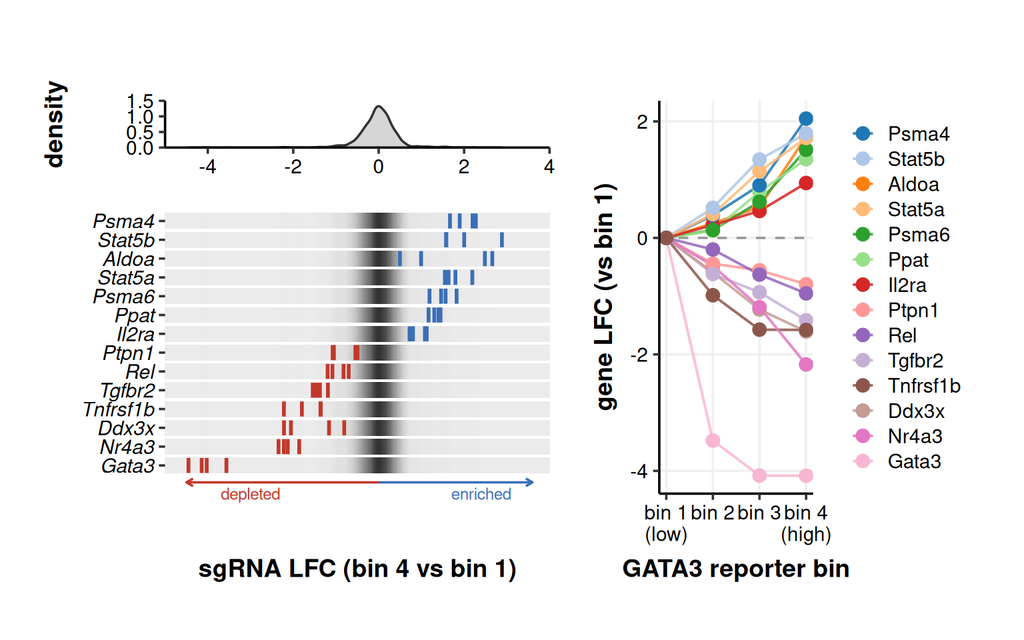

```r
stacked <- (p_top / p_bottom) + plot_layout(heights = c(0.5, 3))
(stacked | p_dose) + plot_layout(widths = c(1, 0.4))
```

```r
ggsave("../../analysis_outs/SIG17_tgfb_tnf/gata3_4_vs_1_sgRNA_lfc_density_dose_test.pdf")
```

```r
# colors
tab20_colors <- c(
  '#1f77b4', '#aec7e8', '#ff7f0e', '#ffbb78', '#2ca02c',
  '#98df8a', '#d62728', '#ff9896', '#9467bd', '#c5b0d5',
  '#8c564b', '#c49c94', '#e377c2', '#f7b6d2',
 # '#7f7f7f', '#c7c7c7',
  '#bcbd22', '#dbdb8d', '#17becf', '#9edae5'
)

gene_levels <- bin4_lfc %>%
  filter(gene %in% plot_genes) %>%
  arrange(desc(lfc4)) %>%
  pull(gene)
gene_pal <- setNames(tab20_colors[seq_along(gene_levels)], gene_levels)

top_long <- gata3_test %>%
  filter(gene %in% plot_genes) %>%
  mutate(gene = factor(gene, levels = gene_levels))

p_dose <- top_long %>%
  ggplot(aes(bin, lfc, group = gene, color = gene)) +
  geom_hline(yintercept = 0, linetype = "dashed", color = "grey60") +
  geom_line(linewidth = 0.7, alpha = 0.85) +
  geom_point(size = 3) +
  scale_color_manual(values = gene_pal, guide = "none") +
  scale_x_continuous(breaks = 1:4,
                     labels = c("bin 1\n(low)", "bin 2", "bin 3", "bin 4\n(high)")) +
  labs(x = "GATA3 reporter bin", y = "gene LFC (vs bin 1)")
```

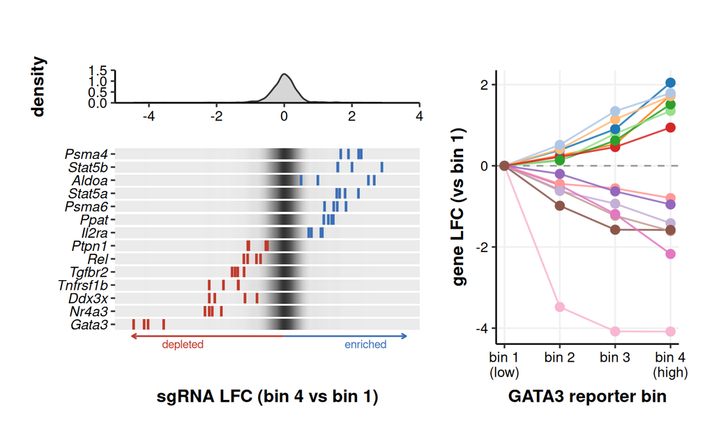

```r
stacked <- (p_top / p_bottom) + plot_layout(heights = c(0.5, 3))
(stacked | p_dose) + plot_layout(widths = c(1, 0.6))
```

```r
ggsave("../../analysis_outs/SIG17_tgfb_tnf/gata3_4_vs_1_sgRNA_lfc_density_dose_noLegend_test.pdf",
       width = 10, height = 5)
```